# In class 10

Some time series capabilites and linear regression using `statsmodels.regression.linear_model.OLS`

INFO 5871-001

## Imports

```python
import pandas as pd
import numpy as np
import matplotlib
import matplotlib.pyplot as plt
import seaborn as sns
import scipy.stats as st
# Avoids certain warning messages later
from pandas.plotting import register_matplotlib_converters
register_matplotlib_converters()
#from sklearn.linear_model import LinearRegression
#from sklearn.metrics import r2_score
import statsmodels.formula.api as sm
```

## Load and set up data

- DonorsChoose donations from 2017
- Index by date
- Sort

# Use this one if downloading from the internet

url = 'http://rodan.cdm.depaul.edu/~rburke/courses/f19/Donations-2017.zip' donations = pd.read_csv(url, compression='zip') print (donations.shape) donations.head()

```python
# If working from a local file, use this one

donations = pd.read_csv('Donations-2017.csv')
```

```python
donations['Date'] = pd.to_datetime(donations['Donation Received Date'])
```

```python
donations = donations.set_index('Date')
```

Not ordered

```python
donations.sort_index(inplace=True)
```

```python
donations = donations[donations['Donation Amount']>0]
```

```python
donations.head()
```

| Date | Project ID | Donation ID | Donor ID | Donation Included Optional Donation | Donation Amount | Donor Cart Sequence | Donation Received Date |
| --- | --- | --- | --- | --- | --- | --- | --- |
| 2017-01-01 00:00:10 | afee0a3394eb66715f859bf2c34e7b27 | ebd3096e770a94af27070f524c485fbf | 66e971a598b7218a39b5a237afabc45f | Yes | 22.99 | 120 | 2017-01-01 00:00:10 |
| 2017-01-01 00:00:28 | 15a3638121712e437780c8186d17df28 | 7ecbed1d197947d77d8539aa0ba165c9 | 0d770de317ea4d05e9ba22315ec148cc | Yes | 99.28 | 15 | 2017-01-01 00:00:28 |
| 2017-01-01 00:00:31 | daac53cd72dd8dbca48bb984e237f91e | d078275af1c2c3c6dc29c03b441a67ae | e73d28c70b91da113fdf9922354610ad | Yes | 100.00 | 3 | 2017-01-01 00:00:31 |
| 2017-01-01 00:00:37 | 0ed8abfbf9704cb9f5934ac4e8991ddc | 2144962e1343980003fdf6305b1a23e9 | 7c51fa4208a1f74b635feab9a3b529c5 | Yes | 75.00 | 2 | 2017-01-01 00:00:37 |
| 2017-01-01 00:02:33 | e1a3b170fb6c31319f4f1193b5c0f083 | 0f77c0e9fe8c7039f2994bef2db664ca | afcacc18fd4bc4141fdf2f0dc6d9def9 | Yes | 10.00 | 15 | 2017-01-01 00:02:33 |

## Resample to daily totals

```python
don_day = donations['Donation Amount'].resample('1D').sum()
don_day.head()
```

```
Date
2017-01-01    152860.69
2017-01-02    146763.16
2017-01-03    141953.25
2017-01-04    142494.35
2017-01-05    126134.30
Freq: D, Name: Donation Amount, dtype: float64
```

### Plot time series

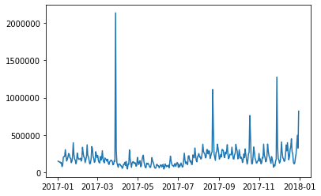

```python
plt.plot(don_day)
```

### There was a big day!

```python
don_day.max()
```

```
2132258.4299999946
```

```python
don_day.idxmax()
```

```
Timestamp('2017-03-29 00:00:00', freq='D')
```

```python
donations.loc['2017-03-29',:].max()
```

```
Project ID                             fff66e951655375179ea06bd5f6f406d
Donation ID                            fffa149a83809584988031ee617dd44b
Donor ID                               ffffdb40226605870f62422b2b420aab
Donation Included Optional Donation                                 Yes
Donation Amount                                                   10000
Donor Cart Sequence                                                8477
Donation Received Date                              2017-03-29 23:59:54
dtype: object
```

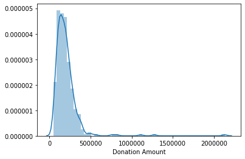

```python
sns.distplot(don_day)
```

```python
don_day_avg = donations['Donation Amount'].resample('1D').mean()
don_day_avg.head()
```

```
Date
2017-01-01    101.165248
2017-01-02     69.130080
2017-01-03     65.749537
2017-01-04     76.940794
2017-01-05     63.352235
Freq: D, Name: Donation Amount, dtype: float64
```

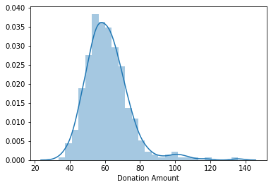

```python
sns.distplot(don_day_avg)
```

```python
don_day_avg.loc['2017-03-29']
```

```
68.44691929892124
```

```python
don_day_ct = donations['Donation Amount'].resample('1D').count()
don_day_ct.head()
```

```
Date
2017-01-01    1511
2017-01-02    2123
2017-01-03    2159
2017-01-04    1852
2017-01-05    1991
Freq: D, Name: Donation Amount, dtype: int64
```

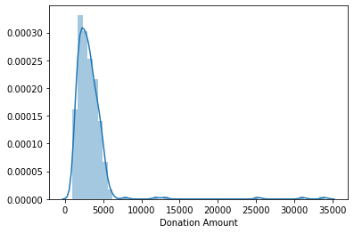

```python
sns.distplot(don_day_ct)
```

```python
don_day_ct['2017-03-29']
```

```
31152
```

```python
don_day_ct.idxmax()
```

```
Timestamp('2017-11-28 00:00:00', freq='D')
```

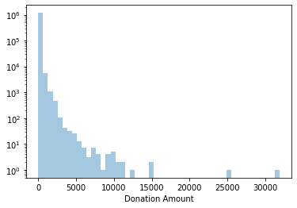

```python
# Initialize figure and ax
fig, ax = plt.subplots()


# Set the scale of the y-axis
ax.set(yscale="log")
sns.distplot(donations['Donation Amount'], kde=False)
```

## Linear relationships

- Does the size of the donation depend on the amount that the teacher needed?
- Does the size of the donation depend on the level of poverty in the school district?

### Load projects information

Filtered from the original data. Contains total project cost and whether funded or not.

# Use this one if downloading from the internet

url = 'http://rodan.cdm.depaul.edu/~rburke/courses/f19/Projects-smaller.zip' projects = pd.read_csv(url, compression='zip') print (projects.shape) projects.head()

```python
# Use this one is loading locally

projects = pd.read_csv('Projects-smaller.csv')
print (projects.shape)
projects.head()
```

```
(1110017, 4)
```

|  | Project ID | School ID | Project Cost | Project Current Status |
| --- | --- | --- | --- | --- |
| 0 | 7685f0265a19d7b52a470ee4bac883ba | e180c7424cb9c68cb49f141b092a988f | 361.80 | Fully Funded |
| 1 | f9f4af7099061fb4bf44642a03e5c331 | 08b20f1e2125103ed7aa17e8d76c71d4 | 512.85 | Expired |
| 2 | afd99a01739ad5557b51b1ba0174e832 | 1287f5128b1f36bf8434e5705a7cc04d | 435.92 | Fully Funded |
| 3 | c614a38bb1a5e68e2ae6ad9d94bb2492 | 900fec9cd7a3188acbc90586a09584ef | 161.26 | Fully Funded |
| 4 | ec82a697fab916c0db0cdad746338df9 | 3b200e7fe3e6dde3c169c02e5fb5ae86 | 264.19 | Fully Funded |

### Load school data

Contains district free lunch percentage

# Use this one if downloading from the internet

url = 'http://rodan.cdm.depaul.edu/~rburke/courses/f19/Schools.zip' schools = pd.read_csv(url, usecols=['School ID', 'School Percentage Free Lunch', 'School State'], compression='zip') print (schools.shape) schools.head()

```python
# Use this one is loading locally

schools = pd.read_csv('Schools.csv',
                      usecols=['School ID', 'School Percentage Free Lunch', 'School State'])
schools.head()
```

|  | School ID | School Percentage Free Lunch | School State |
| --- | --- | --- | --- |
| 0 | 00003e0fdd601b8ea0a6eb44057b9c5e | 56.0 | West Virginia |
| 1 | 00004e32a448b4832e1b993500bf0731 | 41.0 | Texas |
| 2 | 0002021bb799f28de224f1acc1ff08c4 | 2.0 | Washington |
| 3 | 0004604f675212a8cac1161338265196 | 76.0 | Michigan |
| 4 | 0004c9d50bcf0cea990f844e58b5e2c3 | 50.0 | Texas |

### Do some filtering

Trim the high-value outliers and the bulk of the low value donations. Keep between 500 and 12,000

```python
don_amount = donations[['Project ID', 'Donation Amount']]
don_amount.columns = ['Project ID', 'Amount']
don_amount = don_amount.query('Amount < 12000 & Amount > 500')
don_amount.head()
```

| Date | Project ID | Amount |
| --- | --- | --- |
| 2017-01-01 00:06:38 | c13ece1fd84c51238320ce7dddaec8b6 | 2127.48 |
| 2017-01-01 00:06:38 | 21152f6c8266a1f0affcb35dbf452931 | 845.07 |
| 2017-01-01 00:06:38 | dd642082cbd4c060570d7d884ee4353b | 694.39 |
| 2017-01-01 00:06:38 | 67859721a903257470e0a3513173cfbb | 603.40 |
| 2017-01-01 00:06:38 | 1fb07c2f66dc1b4a3d39a6cdefd440c4 | 1058.24 |

### Merge with project info

Remove projects that weren't funded ('Expired') and those asking for more than \$4,000.

```python
don_proj = don_amount.merge(projects, on='Project ID', how='inner')
don_proj = don_proj[don_proj['Project Current Status']!='Expired']
don_proj = don_proj[don_proj['Project Cost'] < 4000]
don_proj.head()
```

|  | Project ID | Amount | School ID | Project Cost | Project Current Status |
| --- | --- | --- | --- | --- | --- |
| 0 | c13ece1fd84c51238320ce7dddaec8b6 | 2127.48 | 71c81ecab2011ff6344a0324e0f2d4fa | 2127.48 | Fully Funded |
| 1 | 21152f6c8266a1f0affcb35dbf452931 | 845.07 | 736f5be3f8374c740ae65f4016bbd9ad | 970.07 | Fully Funded |
| 2 | dd642082cbd4c060570d7d884ee4353b | 694.39 | c76710cff3ebf9f22e0f8cae4ebca2e3 | 1188.39 | Fully Funded |
| 3 | 67859721a903257470e0a3513173cfbb | 603.40 | 527940eb2bb86b6b5ad11864d83ffa70 | 728.40 | Fully Funded |
| 4 | 1fb07c2f66dc1b4a3d39a6cdefd440c4 | 1058.24 | 5729b769d0ec3a5692015fe0ac3793f2 | 1468.24 | Fully Funded |

### Merge with school data

Limit to the state of Colorado. Keep only "Amount", "Total", and "Free Lunch". Drop rows with any missing elements.

```python
don_pfl = don_proj.merge(schools, on='School ID', how='inner')
don_pfl = don_pfl[don_pfl['School State'] == "Colorado"]
don_pfl = don_pfl.drop(['Project ID', 'School ID', 'Project Current Status', 'School State'], axis=1)
don_pfl.columns = ['Amount', 'Total', 'PFL']
don_pfl = don_pfl.dropna()
print (don_pfl.shape)
don_pfl.head()
```

```
(146, 3)
```

|  | Amount | Total | PFL |
| --- | --- | --- | --- |
| 33 | 1206.21 | 2561.42 | 47.0 |
| 34 | 556.86 | 2307.54 | 47.0 |
| 35 | 537.08 | 812.08 | 47.0 |
| 36 | 1000.00 | 3810.01 | 47.0 |
| 410 | 2265.84 | 2290.84 | 26.0 |

## Regession questions

- What's the relationship between project total and donated amount?
- What's the relationship between poverty level (free lunch) and donated amount?

### Scatterplot total vs donated amount

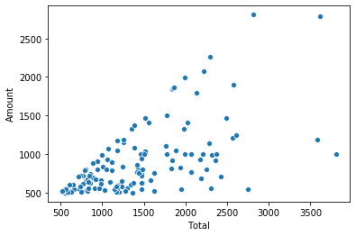

```python
sns.scatterplot(data=don_pfl, x='Total', y='Amount')
```

### Scatterplot free lunch vs donated amount

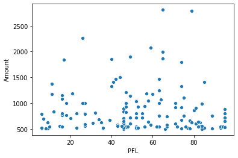

```python
sns.scatterplot(data=don_pfl, x='PFL', y='Amount')
```

### Compute regression total vs amount

- Set up model
- Set up data
- Compute fit
- Show information about fit
- Interplote into scatter plot
- Plot residuals with `residplot`
- Histogram of residuals
- Prob plot with residuals

```python
model1=sm.ols(formula="Amount ~ Total", data=don_pfl)
```

```python
reg1 = model1.fit()
```

```python
reg1.summary()
```

OLS Regression Results

| Dep. Variable: | Amount | R-squared: | 0.391 |
| --- | --- | --- | --- |
| Model: | OLS | Adj. R-squared: | 0.387 |
| Method: | Least Squares | F-statistic: | 92.43 |
| Date: | Sun, 27 Oct 2019 | Prob (F-statistic): | 3.29e-17 |
| Time: | 20:28:48 | Log-Likelihood: | -1060.2 |
| No. Observations: | 146 | AIC: | 2124. |
| Df Residuals: | 144 | BIC: | 2130. |
| Df Model: | 1 |  |  |
| Covariance Type: | nonrobust |  |  |

|  | coef | std err | t | P>\|t\| | [0.025 | 0.975] |
| --- | --- | --- | --- | --- | --- | --- |
| Intercept | 324.5746 | 63.804 | 5.087 | 0.000 | 198.461 | 450.689 |
| Total | 0.4035 | 0.042 | 9.614 | 0.000 | 0.321 | 0.486 |

| Omnibus: | 30.521 | Durbin-Watson: | 1.597 |
| --- | --- | --- | --- |
| Prob(Omnibus): | 0.000 | Jarque-Bera (JB): | 54.875 |
| Skew: | 0.973 | Prob(JB): | 1.21e-12 |
| Kurtosis: | 5.288 | Cond. No. | 3.38e+03 |

Warnings:  
[1] Standard Errors assume that the covariance matrix of the errors is correctly specified.  
[2] The condition number is large, 3.38e+03. This might indicate that there are  
strong multicollinearity or other numerical problems.

```python
y_pred1 = reg1.predict(don_pfl.Total)
```

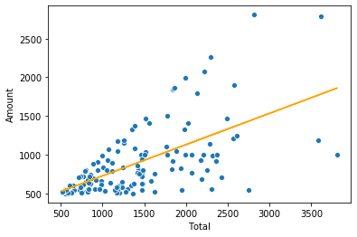

```python
sns.scatterplot(data=don_pfl, x='Total', y='Amount')
plt.plot(don_pfl.Total, y_pred1, color = 'orange')
plt.show()
```

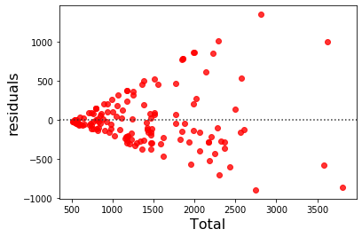

```python
sns.residplot(don_pfl.Total, reg1.resid, color = 'red')
plt.xlabel('Total', fontsize = 16)
plt.ylabel('residuals', fontsize = 16)
plt.show();
```

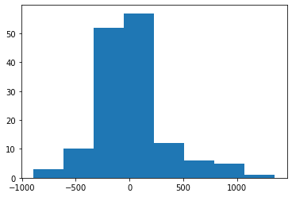

```python
plt.hist(reg1.resid, bins = 8)
plt.show();
```

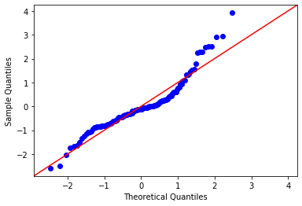

```python
from statsmodels.graphics.gofplots import qqplot

p = qqplot(reg1.resid_pearson,line='45',fit='True')
```

### Conclusion

Not too bad but heteroskedasticity is a problem.

```python
model2=sm.ols(formula="Amount ~ PFL", data=don_pfl)
```

```python
reg2 = model2.fit()
```

```python
reg2.summary()
```

OLS Regression Results

| Dep. Variable: | Amount | R-squared: | 0.001 |
| --- | --- | --- | --- |
| Model: | OLS | Adj. R-squared: | -0.006 |
| Method: | Least Squares | F-statistic: | 0.09118 |
| Date: | Sun, 27 Oct 2019 | Prob (F-statistic): | 0.763 |
| Time: | 20:28:49 | Log-Likelihood: | -1096.3 |
| No. Observations: | 146 | AIC: | 2197. |
| Df Residuals: | 144 | BIC: | 2203. |
| Df Model: | 1 |  |  |
| Covariance Type: | nonrobust |  |  |

|  | coef | std err | t | P>\|t\| | [0.025 | 0.975] |
| --- | --- | --- | --- | --- | --- | --- |
| Intercept | 896.0940 | 86.865 | 10.316 | 0.000 | 724.400 | 1067.788 |
| PFL | -0.4505 | 1.492 | -0.302 | 0.763 | -3.399 | 2.498 |

| Omnibus: | 74.624 | Durbin-Watson: | 1.666 |
| --- | --- | --- | --- |
| Prob(Omnibus): | 0.000 | Jarque-Bera (JB): | 239.888 |
| Skew: | 2.057 | Prob(JB): | 8.11e-53 |
| Kurtosis: | 7.745 | Cond. No. | 138. |

Warnings:  
[1] Standard Errors assume that the covariance matrix of the errors is correctly specified.

### Conclusion

Garbage. Note that $R^2$ is not even 1%. There is no relationship between poverty and the amount donated.